# N736 Homework 7 Answer Key

Melinda K. Higgins, PhD.

November 23, 2017

## Repeated Measures ANOVA and Multilevel (mixed) Linear Model (MLM)

For Homework 7, we’re be working with the HELP (`helpmkh`) dataset. Load the data and select the variables:

- `id`
- `treat`
- `cesd`, `cesd1`, `cesd2`, `cesd3`, `cesd4`

```r
library(tidyverse)
library(haven)

helpdat <- haven::read_spss("helpmkh.sav")

h1 <- helpdat %>%
  select(id, treat, cesd, cesd1, cesd2, cesd3, cesd4)
```

### Select Complete Cases

To do a repeated measures ANOVA, for which most software packages like SAS and SPSS use listwise deletion, we need to select only the 98 cases with complete data, i.e. no missing or skipped data for the 5 time points of CESD measurements.

```r
# compute number of missing values
# across the 5 time points of cesd measurements
h1$nmiss_cesd <- rowSums(is.na(h1[,3:7]))
table(h1$nmiss_cesd)
```

```
##
##  0  1  2  3  4
## 98 98 96 91 70
```

```r
# keep only the 98 cases with complete data
# where nmiss_cesd equals 0 (none missing)
h198 <- h1 %>%
  filter(nmiss_cesd==0)
```

### Restructure from WIDE into LONG format

Next, put the data into a long format - there should be 98*5 = 490 rows of data.

```r
# put into a long format
h198long <- h198 %>%
  gather(key=item,
         value=value,
         -c(id,treat,nmiss_cesd))

# rename the variables
names(h198long) <- c("id","treat",
                     "nmiss_cesd","cesditem","cesdvalue")

# add a time variable to long format
h198long <- h198long %>%
  mutate(time=c(rep(0,98),
                rep(1,98),
                rep(2,98),
                rep(3,98),
                rep(4,98)))
```

### RM-ANOVA

For an example, see # see http://psych.wisc.edu/moore/Rpdf/610-R11_MixedDesign.pdf

We need to convert the subject `id`, `treat` treatment group and `time` within subject into factors.

```r
# conver these into factors
h198long$id <- factor(h198long$id) # subject id
h198long$treat <- factor(h198long$treat) # group - between factor
h198long$time <- factor(h198long$time) # time - within factor
```

### Use `aov()` function to perform RM-ANOVA

When we set this up, we need to add the `Error()` term with `id/time` which tells the model that `time` is nested within subject `id`.

```r
m2 <- aov(cesdvalue ~ treat*time + Error(id/time),
          data=h198long)
summary(m2)
```

```
##
## Error: id
##           Df Sum Sq Mean Sq F value Pr(>F)
## treat      1    445   445.5   0.865  0.355
## Residuals 96  49435   515.0
##
## Error: id:time
##             Df Sum Sq Mean Sq F value Pr(>F)
## time         4  11357  2839.2  35.680 <2e-16 ***
## treat:time   4    671   167.8   2.109 0.0791 .
## Residuals  384  30556    79.6
## ---
## Signif. codes:  0 '***' 0.001 '**' 0.01 '*' 0.05 '.' 0.1 ' ' 1
```

### Effects Plots

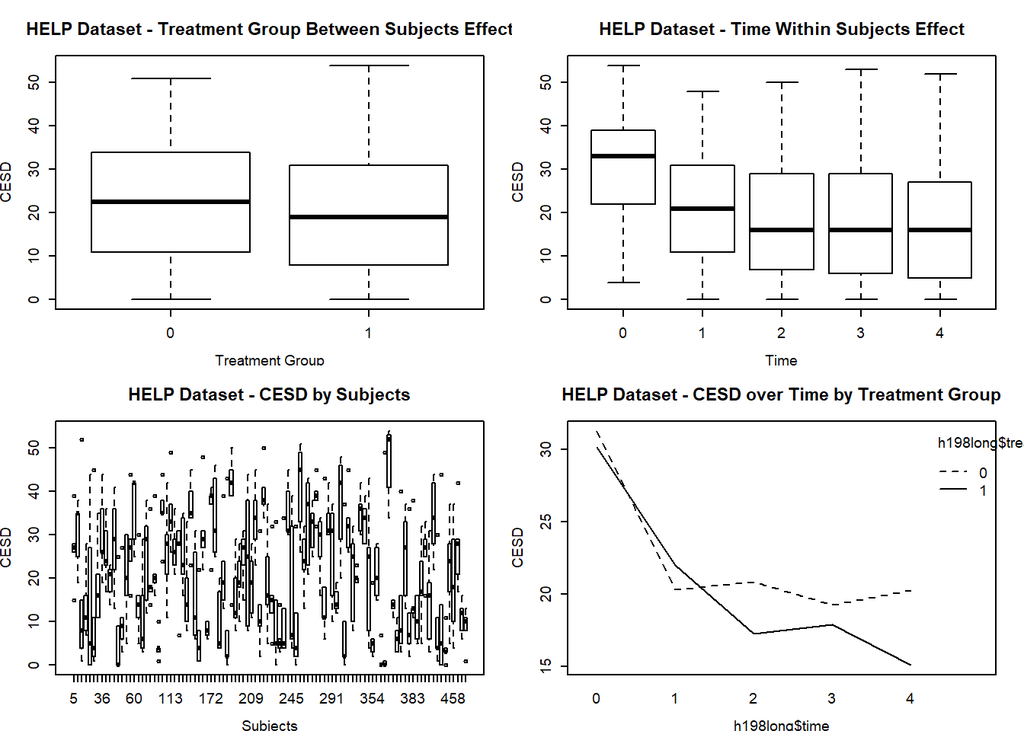

```r
# Graphs - Main effects and interaction graphs
par(mfrow=c(2, 2), cex=0.6, mar=c(4, 4, 4, 2), mex=0.8)

# sets up for 4 graphs on a page. The next 4 statements ask for main effect means, then the Group x Time interaction effect.
plot(h198long$cesdvalue ~ h198long$treat,
     main="HELP Dataset - Treatment Group Between Subjects Effect",
     xlab="Treatment Group", ylab="CESD")
plot(h198long$cesdvalue ~ h198long$time,
     main="HELP Dataset - Time Within Subjects Effect",
     xlab="Time",ylab="CESD")
plot(h198long$cesdvalue ~ h198long$id,
     main="HELP Dataset - CESD by Subjects",
     xlab="Subjects",ylab="CESD")
interaction.plot(h198long$time,
                 h198long$treat,
                 h198long$cesdvalue,
                 main="HELP Dataset - CESD over Time by Treatment Group",
                 ylab="CESD")
```

## Multilevel (MIXED) Linear Model (MLM)

For this approach, let’s use all available (non-missing) data. So, some subjects may have complete data and others may only have 1 or 2 time points of data.

```r
h1 <- helpdat %>%
  select(id, treat, cesd, cesd1, cesd2, cesd3, cesd4)

# use all available data
# restructure into long format

h1long <- h1 %>%
  gather(key=item,
         value=value,
         -c(id,treat),
         na.rm=FALSE)

names(h1long) <- c("id","treat","cesditem","cesdvalue")

# add a time variable to long format
h1long <- h1long %>%
  mutate(time=c(rep(0,453),
                rep(1,453),
                rep(2,453),
                rep(3,453),
                rep(4,453)))
```

### Error Bar Plots using code from the R-Cookbook

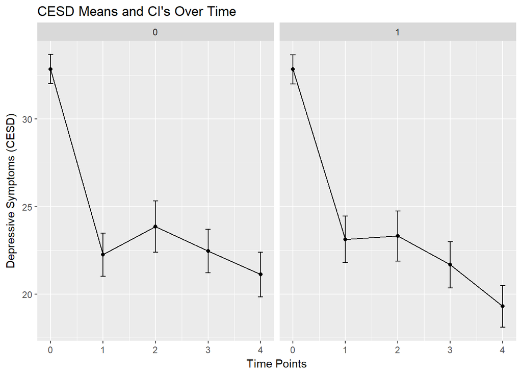

```r
# Error Bar Plots
# from the cookbook for R
## Gives count, mean, standard deviation, standard error of the mean, and confidence interval (default 95%).
##   data: a data frame.
##   measurevar: the name of a column that contains the variable to be summariezed
##   groupvars: a vector containing names of columns that contain grouping variables
##   na.rm: a boolean that indicates whether to ignore NA's
##   conf.interval: the percent range of the confidence interval (default is 95%)
summarySE <- function(data=NULL, measurevar, groupvars=NULL, na.rm=FALSE,
                      conf.interval=.95, .drop=TRUE) {
  library(plyr)

  # New version of length which can handle NA's: if na.rm==T, don't count them
  length2 <- function (x, na.rm=FALSE) {
    if (na.rm) sum(!is.na(x))
    else       length(x)
  }

  # This does the summary. For each group's data frame, return a vector with
  # N, mean, and sd
  datac <- ddply(data, groupvars, .drop=.drop,
                 .fun = function(xx, col) {
                   c(N    = length2(xx[[col]], na.rm=na.rm),
                     mean = mean   (xx[[col]], na.rm=na.rm),
                     sd   = sd     (xx[[col]], na.rm=na.rm)
                   )
                 },
                 measurevar
  )

  # Rename the "mean" column
  datac <- rename(datac, c("mean" = measurevar))

  datac$se <- datac$sd / sqrt(datac$N)  # Calculate standard error of the mean

  # Confidence interval multiplier for standard error
  # Calculate t-statistic for confidence interval:
  # e.g., if conf.interval is .95, use .975 (above/below), and use df=N-1
  ciMult <- qt(conf.interval/2 + .5, datac$N-1)
  datac$ci <- datac$se * ciMult

  return(datac)
}

h1long_nomiss <- na.omit(h1long)
#table(h1long_nomiss$time)

h1se <- summarySE(h1long_nomiss,
                  measurevar="cesdvalue",
                  groupvars=c("time","treat"))

ggplot(h1se, aes(x=time, y=cesdvalue)) +
  geom_errorbar(aes(ymin=cesdvalue-se, ymax=cesdvalue+se),
                width=.1) +
  geom_line() +
  geom_point() +
  xlab("Time Points") +
  ylab("Depressive Symptoms (CESD)") +
  ggtitle("CESD Means and CI's Over Time") +
  facet_wrap(~treat)
```

### MLM models

```r
# MLM Approach
# use nlme package
library(nlme)

lme1 <- nlme::lme(cesdvalue ~ time*treat,
            data=h1long,
            random= ~1 | id,
            method="REML",
            na.action=na.omit)
# get summary - model coefficients
# tests coefficients not equal to 0
summary(lme1)
```

```
## Linear mixed-effects model fit by REML
##  Data: h1long
##        AIC     BIC   logLik
##   11208.56 11240.1 -5598.28
##
## Random effects:
##  Formula: ~1 | id
##         (Intercept) Residual
## StdDev:    9.655901 10.11562
##
## Fixed effects: cesdvalue ~ time * treat
##                 Value Std.Error  DF  t-value p-value
## (Intercept) 30.778989 0.8699977 967 35.37824  0.0000
## time        -2.626044 0.2683068 967 -9.78747  0.0000
## treat        0.165015 1.2295777 451  0.13420  0.8933
## time:treat  -0.412528 0.3719693 967 -1.10904  0.2677
##  Correlation:
##            (Intr) time   treat
## time       -0.473
## treat      -0.708  0.334
## time:treat  0.341 -0.721 -0.478
##
## Standardized Within-Group Residuals:
##         Min          Q1         Med          Q3         Max
## -2.41023282 -0.62607170 -0.04357131  0.58091139  3.26478926
##
## Number of Observations: 1422
## Number of Groups: 453
```

```r
# get anova tables - both
# of these yield type III Sums of Squares
anova.lme(lme1, type="marginal")
```

```
##             numDF denDF   F-value p-value
## (Intercept)     1   967 1251.6201  <.0001
## time            1   967   95.7946  <.0001
## treat           1   451    0.0180  0.8933
## time:treat      1   967    1.2300  0.2677
```

```r
car::Anova(lme1, type="III")
```

```
## Analysis of Deviance Table (Type III tests)
##
## Response: cesdvalue
##                Chisq Df Pr(>Chisq)
## (Intercept) 1251.620  1     <2e-16 ***
## time          95.795  1     <2e-16 ***
## treat          0.018  1     0.8932
## time:treat     1.230  1     0.2674
## ---
## Signif. codes:  0 '***' 0.001 '**' 0.01 '*' 0.05 '.' 0.1 ' ' 1
```

### MLM again with `treat` coding flipped

It is always a good idea to flip the coding for a dichotomous variable (`treat`) and double check the interaction term.

```r
# you can also use the lme4 package
# read more at https://freshbiostats.wordpress.com/2013/07/28/mixed-models-in-r-lme4-nlme-both/
# and just google nlme vs lme4 package

# flip treat and run again
h1long <- h1long %>%
  mutate(treat_flip = as.numeric(treat==0))

lme2 <- nlme::lme(cesdvalue ~ time*treat_flip,
            data=h1long,
            random= ~1 | id,
            method="REML",
            na.action=na.omit)
# get summary - model coefficients
# tests coefficients not equal to 0
summary(lme2)
```

```
## Linear mixed-effects model fit by REML
##  Data: h1long
##        AIC     BIC   logLik
##   11208.56 11240.1 -5598.28
##
## Random effects:
##  Formula: ~1 | id
##         (Intercept) Residual
## StdDev:    9.655901 10.11562
##
## Fixed effects: cesdvalue ~ time * treat_flip
##                     Value Std.Error  DF   t-value p-value
## (Intercept)     30.944004 0.8688874 967  35.61336  0.0000
## time            -3.038572 0.2576289 967 -11.79437  0.0000
## treat_flip      -0.165015 1.2295777 451  -0.13420  0.8933
## time:treat_flip  0.412528 0.3719693 967   1.10904  0.2677
##  Correlation:
##                 (Intr) time   trt_fl
## time            -0.483
## treat_flip      -0.707  0.341
## time:treat_flip  0.334 -0.693 -0.478
##
## Standardized Within-Group Residuals:
##         Min          Q1         Med          Q3         Max
## -2.41023282 -0.62607170 -0.04357131  0.58091139  3.26478926
##
## Number of Observations: 1422
## Number of Groups: 453
```

```r
# get anova tables - both
# of these yield type III Sums of Squares
anova.lme(lme2, type="marginal")
```

```
##                 numDF denDF   F-value p-value
## (Intercept)         1   967 1268.3116  <.0001
## time                1   967  139.1073  <.0001
## treat_flip          1   451    0.0180  0.8933
## time:treat_flip     1   967    1.2300  0.2677
```

```r
car::Anova(lme2, type="III")
```

```
## Analysis of Deviance Table (Type III tests)
##
## Response: cesdvalue
##                    Chisq Df Pr(>Chisq)
## (Intercept)     1268.312  1     <2e-16 ***
## time             139.107  1     <2e-16 ***
## treat_flip         0.018  1     0.8932
## time:treat_flip    1.230  1     0.2674
## ---
## Signif. codes:  0 '***' 0.001 '**' 0.01 '*' 0.05 '.' 0.1 ' ' 1
```